# Aggregation example

RW Hass

2025-02-11

## What is aggregation?

Aggregation loosely refers to summarizing over a set of lower level cases in a hierarchically nested data structure. For example, let’s say we have information about patients, and about the clinics they’re seen in, or their doctors.

We may want to test hypotheses about how characteristics of a doctor relate to patient outcomes. Using ordinary least squares, we can either leave the data at the patient level or *aggregate* the patients’ outcomes to get doctor-level patient outcomes (i.e., mean satisfaction per doctor).

Today we’ll explore how the choice of modeling effects inferences. Specifically, the standard errors used to compute confidence intervals and $p$-values.

- **Note: this vignette relies on `jtools`, `ggplot2` and `lme4` and part 2 was adapted from** [this post by Francis Huang](https://francish.net/post/simulating-a-multilevel-model/)

### Simpson’s paradox

A related issue is [Simpson’s paradox](https://en.wikipedia.org/wiki/Simpson%27s_paradox). The issue does not just affect clustered data, but is more general in that it addresses the fact that when we ignore grouping structures in data we can come to erroneous conclusions.

To illustrate, here’s a hypothetical data set constructed specifically for this example (from the [Snijders and Bosker book](https://www.stats.ox.ac.uk/~snijders/mlbook.htm)) with $J = 5$ clusters, each with an $n = 2$ for an overall $N = 10$

```
##    Participant Cluster Outcome Predictor
## 1            1       1       5         1
## 2            2       1       7         3
## 3            3       2       4         2
## 4            4       2       6         4
## 5            5       3       3         3
## 6            6       3       5         5
## 7            7       4       2         4
## 8            8       4       4         6
## 9            9       5       1         5
## 10          10       5       3         7
```

Let’s fit a linear model for the `Outcome` ignoring the `Cluster` variable and plot the result:

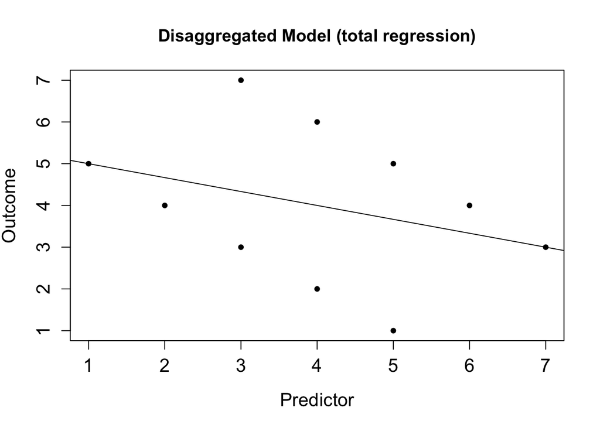

| Observations | 10 |
| --- | --- |
| Dependent variable | Outcome |
| Type | OLS linear regression |

| F(1,8) | 1.00 |
| --- | --- |
| R² | 0.11 |
| Adj. R² | 0.00 |

|  | Est. | S.E. | t val. | p |
| --- | --- | --- | --- | --- |
| (Intercept) | 5.33 | 1.45 | 3.67 | 0.01 |
| Predictor | -0.33 | 0.33 | -1.00 | 0.35 |

Standard errors: OLS

If we weren’t aware of the different clusters, we might accept that the fit is poor, but still see that there’s a negative linear association between the `Predictor` and the `Outcome`

#### The between-groups effect

Let’s aggregate up, creating a new data set with $N = 5$ representing the relationship between the *mean* predictor and *mean* outcome across the groups:

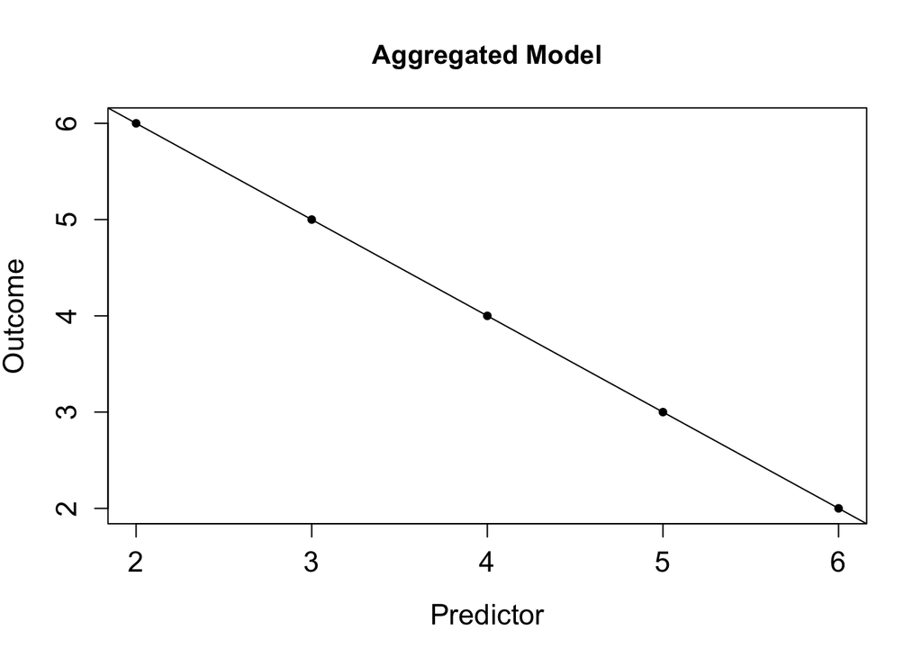

| Observations | 5 |
| --- | --- |
| Dependent variable | Outcome |
| Type | OLS linear regression |

| F(1,3) | 358547929328243995167855753560064.00 |
| --- | --- |
| R² | 1.00 |
| Adj. R² | 1.00 |

|  | Est. | S.E. | t val. | p |
| --- | --- | --- | --- | --- |
| (Intercept) | 8.00 | 0.00 | 35704860762310480.00 | 0.00 |
| Predictor | -1.00 | 0.00 | -18935361874763416.00 | 0.00 |

Standard errors: OLS

Now we have a perfect fit, and it’s still negative. Note, we have no standard errors here, but that’s fine. We’ll see more on that later.

The final option would be to simply look within each group, and somehow summarize over that. For each group, it turns out the following regression equation holds perfectly:

$$Y_{ij} = \bar{Y}_{.j} + 1.00(X_{ij} - \bar{X}_{.j}) + r_{ij}$$

That is, *within* each group, the relationship between predictor and outcome is positive, as shown below!

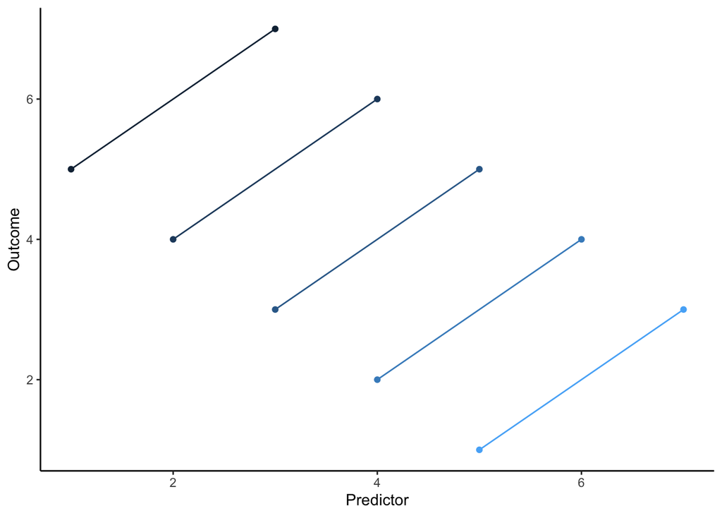

These data were actually generated using a multilevel model, but are quite unrealistic. Let’s see what a more realistic, though synthetic example might look like.

### Example 2

Though Simpson’s paradox is not always common, the more important point not seen in the above is that the way you aggregate, or don’t, also affects standard errors, so it will effect the nature of the inferences, even if the signs don’t change in and between clusters.

As a more realistic demonstration, I’ve simulated a dataset with equal cluster sizes ($N_{j} = 30$), and $J = 20$ clusters. The variables are:

```r
set.seed(1234) #for reproducability
nG <- 20 #number of groups
nJ <- 30 #cluster size
W1 <- .2 #level 2 coeff
X1 <- 0.75 #level 1 coeff
intcep <- 0.34

tmp2 <- rnorm(nG, mean = 0, sd = 3) #generate 20 random numbers, m = 0, sd = 1
l2 <- rep(tmp2, each = nJ) #all units in l2 have the same value
group <- gl(nG, k = nJ) #creating cluster variable
tmp2 <- rnorm(nG) #error term for level 2
err2 <- rep(tmp2, each = nJ) #all units in l2 have the same value

l1 <- rnorm(nG * nJ) #total sample size is nG * nJ
err1 <- rnorm(nG * nJ, sd = 4) #level 1

#putting it all together
y <- intcep + W1 * l2 + X1 * l1 + err2 + err1
dat <- data.frame(y, group, l2, err2,l1, err1)
```

### Visualize

Let’s first have a look at the overall relationship between anxiety (`l1`) and pain ($Y$)

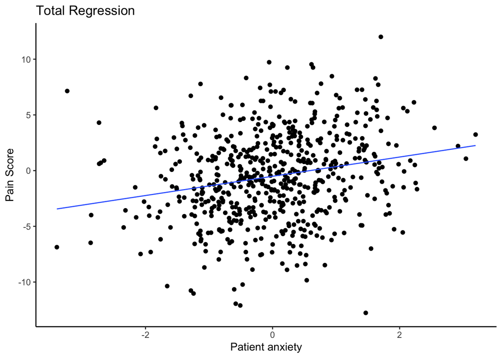

### Unclustered / dis-aggregated model

Let’s fit linear model for the total regression, ignoring all the clusters, and including the level 2 (`l2`) variable.

```r
unclustered <- lm(y ~ l1 + l2, data = dat)

summ(unclustered)
```

| Observations | 600 |
| --- | --- |
| Dependent variable | y |
| Type | OLS linear regression |

| F(2,597) | 17.69 |
| --- | --- |
| R² | 0.06 |
| Adj. R² | 0.05 |

|  | Est. | S.E. | t val. | p |
| --- | --- | --- | --- | --- |
| (Intercept) | -0.42 | 0.16 | -2.54 | 0.01 |
| l1 | 0.86 | 0.16 | 5.46 | 0.00 |
| l2 | 0.12 | 0.05 | 2.23 | 0.03 |

Standard errors: OLS

### Agreggate model

Now, let’s do the between-groups regression. We’ll need to aggregate `l1` up to the group level. So now each group will have a value for `l1` representing the mean score on that variable in the group, and then `l2` that only varies at the group level

```
## # A tibble: 20 × 4
##    group  mean.l1  mean.y     l2
##    <fct>    <dbl>   <dbl>  <dbl>
##  1 1     -0.0907  -1.57   -3.62
##  2 2      0.120   -0.149   0.832
##  3 3     -0.0359   0.0230  3.25
##  4 4      0.0498   0.0336 -7.04
##  5 5      0.233    0.240   1.29
##  6 6      0.0401  -1.10    1.52
##  7 7      0.201    0.503  -1.72
##  8 8      0.233   -1.23   -1.64
##  9 9     -0.0654   0.353  -1.69
## 10 10     0.0235  -1.40   -2.67
## 11 11     0.114    0.158  -1.43
## 12 12    -0.168    0.0971 -3.00
## 13 13    -0.172   -1.93   -2.33
## 14 14     0.0392  -0.232   0.193
## 15 15    -0.0704  -1.49    2.88
## 16 16     0.0850   0.165  -0.331
## 17 17     0.0603  -2.07   -1.53
## 18 18    -0.429   -1.30   -2.73
## 19 19     0.0356  -0.857  -2.51
## 20 20     0.00721  1.78    7.25
```

```r
agg <- lm(mean.y ~ mean.l1 + l2, data = agg_dat_join)
summ(agg)
```

| Observations | 20 |
| --- | --- |
| Dependent variable | mean.y |
| Type | OLS linear regression |

| F(2,17) | 2.24 |
| --- | --- |
| R² | 0.21 |
| Adj. R² | 0.12 |

|  | Est. | S.E. | t val. | p |
| --- | --- | --- | --- | --- |
| (Intercept) | -0.43 | 0.22 | -1.99 | 0.06 |
| mean.l1 | 1.55 | 1.40 | 1.11 | 0.28 |
| l2 | 0.11 | 0.07 | 1.61 | 0.13 |

Standard errors: OLS

Let’s see how this looks in a scatterplot

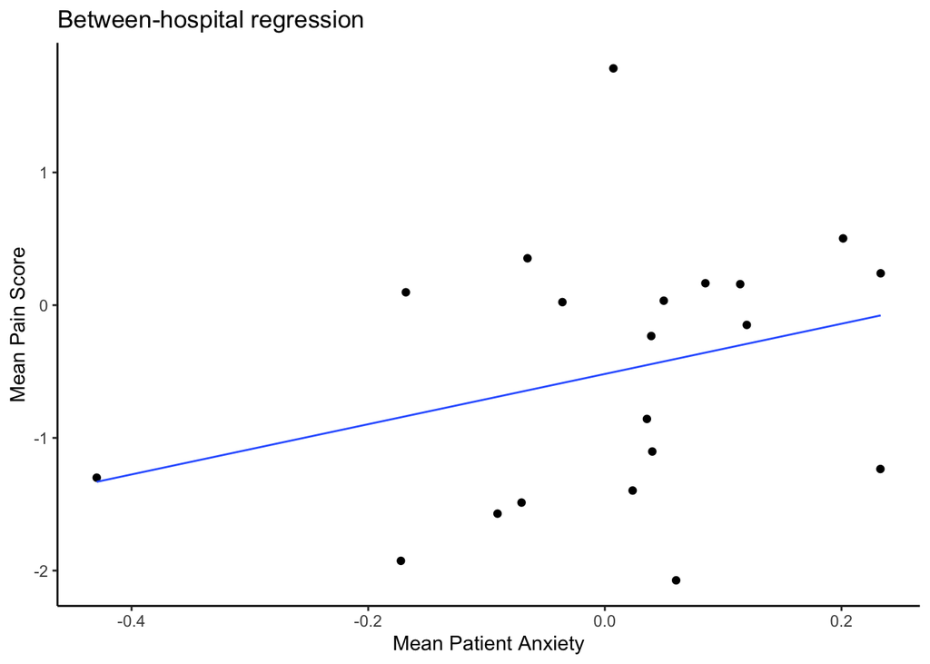

We can also get a more realistic look at the relationship between pain management efficiency (`l2`) and mean patient pain score (`mean.y`)

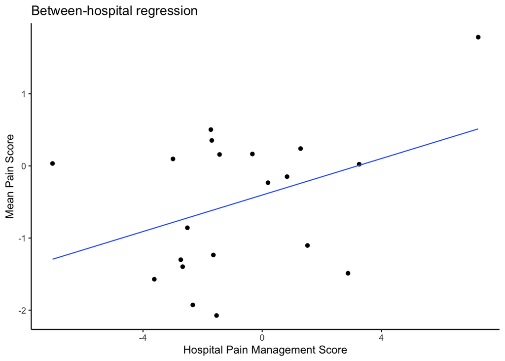

### Multilevel Model

Now let’s have a look at the scatterplot for the level-1 variable again, but this time, we’ll see how the patient-level pain-anxiety relationship might vary between the groups

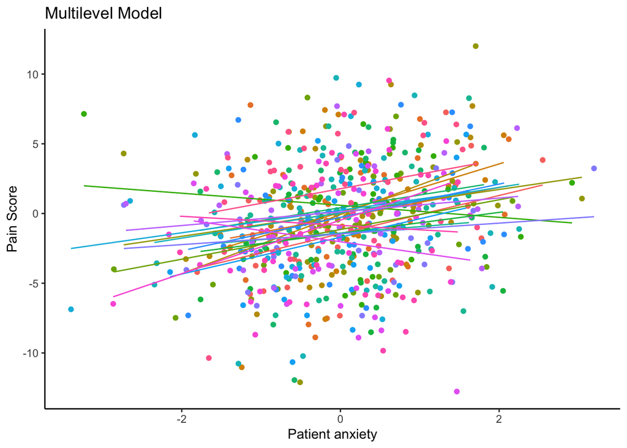

So there’s at least 1 group where the anxiety-pain relationship is flatter than the others. We’ll now fit a linear mixed-effects regression to handle this multilevel nested structure. Note that the standard errors will be different as well as the output.

First, we’ll fit what we’ll learn to call the **unconditional** model. This seems boring, but the idea is that we don’t specify anything but the random-effects for group. The output gives us the estimate of the intraclass correlation (ICC), as well as how much the group intercepts are varying

```r
mm_mod <- lmer(y ~ (1 | group), dat)
summ(mm_mod)
```

| Observations | 600 |
| --- | --- |
| Dependent variable | y |
| Type | Mixed effects linear regression |

| AIC | 3369.06 |
| --- | --- |
| BIC | 3382.26 |
| Pseudo-R² (fixed effects) | 0.00 |
| Pseudo-R² (total) | 0.03 |

| Fixed Effects | Fixed Effects Est. | Fixed Effects S.E. | Fixed Effects t val. | Fixed Effects d.f. | Fixed Effects p |
| --- | --- | --- | --- | --- | --- |
| (Intercept) | -0.50 | 0.22 | -2.25 | 19.00 | 0.04 |

p values calculated using Satterthwaite d.f.

| Random Effects Group | Random Effects Parameter | Random Effects Std. Dev. |
| --- | --- | --- |
| group | (Intercept) | 0.68 |
| Residual |  | 3.95 |

| Grouping Variables Group | Grouping Variables # groups | Grouping Variables ICC |
| --- | --- | --- |
| group | 20 | 0.03 |

Now we’ll fit what we’ll learn to call the **random-effects ANCOVA** where we allow for the intercepts to vary across groups, as well as the effect of `l1`. We’ll get a residual ICC as well as information about the variation of these effects.

Also notice the strange $df$ values. We’ll have more to say about that in coming weeks.

```r
mm_mod1 <- lmer(y ~ l1 + l2 + (l1| group), data = dat)
```

```
## boundary (singular) fit: see help('isSingular')
```

```r
summ(mm_mod1)
```

| Observations | 600 |
| --- | --- |
| Dependent variable | y |
| Type | Mixed effects linear regression |

| AIC | 3349.97 |
| --- | --- |
| BIC | 3380.75 |
| Pseudo-R² (fixed effects) | 0.06 |
| Pseudo-R² (total) | 0.08 |

| Fixed Effects | Fixed Effects Est. | Fixed Effects S.E. | Fixed Effects t val. | Fixed Effects d.f. | Fixed Effects p |
| --- | --- | --- | --- | --- | --- |
| (Intercept) | -0.42 | 0.21 | -1.97 | 18.26 | 0.06 |
| l1 | 0.85 | 0.16 | 5.37 | 116.88 | 0.00 |
| l2 | 0.12 | 0.07 | 1.80 | 18.54 | 0.09 |

p values calculated using Satterthwaite d.f.

| Random Effects Group | Random Effects Parameter | Random Effects Std. Dev. |
| --- | --- | --- |
| group | (Intercept) | 0.58 |
| group | l1 | 0.12 |
| Residual |  | 3.85 |

| Grouping Variables Group | Grouping Variables # groups | Grouping Variables ICC |
| --- | --- | --- |
| group | 20 | 0.02 |

Here are the coefficients and standard errors from the mixed model and the dis-aggregated model:

Ordinary Least Squares

|  | Estimate | Std. Error | t value |
| --- | --- | --- | --- |
| (Intercept) | -0.4175 | 0.1641 | -2.5447 |
| l1 | 0.8557 | 0.1567 | 5.4603 |
| l2 | 0.1199 | 0.0537 | 2.2340 |

Linear Mixed Effects

|  | Estimate | Std. Error | t value |
| --- | --- | --- | --- |
| (Intercept) | -0.4154 | 0.2106 | -1.9727 |
| l1 | 0.8502 | 0.1583 | 5.3725 |
| l2 | 0.1232 | 0.0684 | 1.7996 |

## Summary

1. When data are naturally nested, ignoring that structure and analyzing the data as if no grouping structure produces biased standard errors (usually too small).
2. Aggregating up may make it look like the overall fit is good ($R^{2}$) but we lose power, and we can no longer make inferences about individuals (SE’s are larger due to smaller sample size at group level)
3. Using random effects, we can use a multilevel model to parse out the variation within and between groups to get a less biased view of what’s going on
4. There are other options to adjust SE’s, but not when we are interested in level-2 effects